# Predicting Survival Outcomes Using Logistic Regression

Yafet Mekonnen (Advisor: Dr. Cohen)

2026-04-20

## Introduction

- Many real-world outcomes are binary (Yes/No, Sick/Healthy)
- Linear regression is not suitable because it can predict invalid values (e.g., negative or >1)
- Logistic regression is designed for binary outcomes
- Uses log-odds (logit function) and converts results into probabilities (0–1)
- Widely used in healthcare to predict risk and support decision-making

## Evaluation Metrics

- Logistic regression uses the log-odds (logit) to transform the function written as

$\log\left(\frac{p}{1 - p}\right) = \beta_0 + \beta_1 X_1 + \dots + \beta_k X_k$

Where:

- $p$ is the probability that the event occurs
- $\beta_0$ is the intercept
- $\beta_1, \dots, \beta_k$ are coefficients
- $X_1, \dots, X_k$ are predictor variables

## Evaluation Metrics 2

- Accuracy is calculated as $Accuracy = \frac{TP + TN}{TP + TN + FP + FN}$,
- Precision is calculated as $Precision = \frac{TP}{TP + FP}$,
- Recall is calculated as $Recall = \frac{TP}{TP + FN}$,
- F1 score is calculated as $F1 = 2 \times \frac{Precision \times Recall}{Precision + Recall}$.
- A confusion matrix is used to compare predicted and actual outcomes.
- The ROC curve and AUC score help measure how good the model is at correctly separating the two groups.

## Data Exploration

- Dataset from Kaggle (Framingham Heart Study)
- Long-term cardiovascular study in Framingham, Massachusetts
- Tracked patients over 10 years
- Contains 4,238 patient records & 15 features (demographic, behavioral, medical)
- Goal is to Predict coronary heart disease (CHD),Analyze how risk factors affect heart disease over time
- Each feature represents a potential risk factor
- Helps model understand patient health patterns

## Table: Description of Features

| Variable | Description |
| --- | --- |
| male | Sex of the participant, (1 = male, 0 = female). |
| age | Age of the participant. |
| education | Education level (1 = some high school, 2 = high school graduate or GED, 3 = some college, 4 = college graduate). |
| currentSmoker | Indicates whether or not the patient is a current smoker. |
| cigsPerDay | Average number of cigarettes smoked per day. |
| BPMeds | Whether the participant is taking medication for blood pressure. |
| prevalentStroke | Whether the participant has ever experienced a stroke. |
| prevalentHyp | whether or not the patient was hypertensive. |
| diabetes | Whether the participant has been diagnosed with diabetes. |
| totChol | Cholesterol level of the participant. |
| sysBP | Systolic blood pressure. |
| diaBP | Diastolic blood pressure. |
| BMI | Body Mass Index (BMI). |
| heartRate | Heart rate of the participant. |
| glucose | Glucose level. |
| TenYearCHD | Outcome variable indicating whether the participant developed coronary heart disease (CHD) within 10 years (1 = Yes, 0 = No). |

## Heart Disease Outcomes

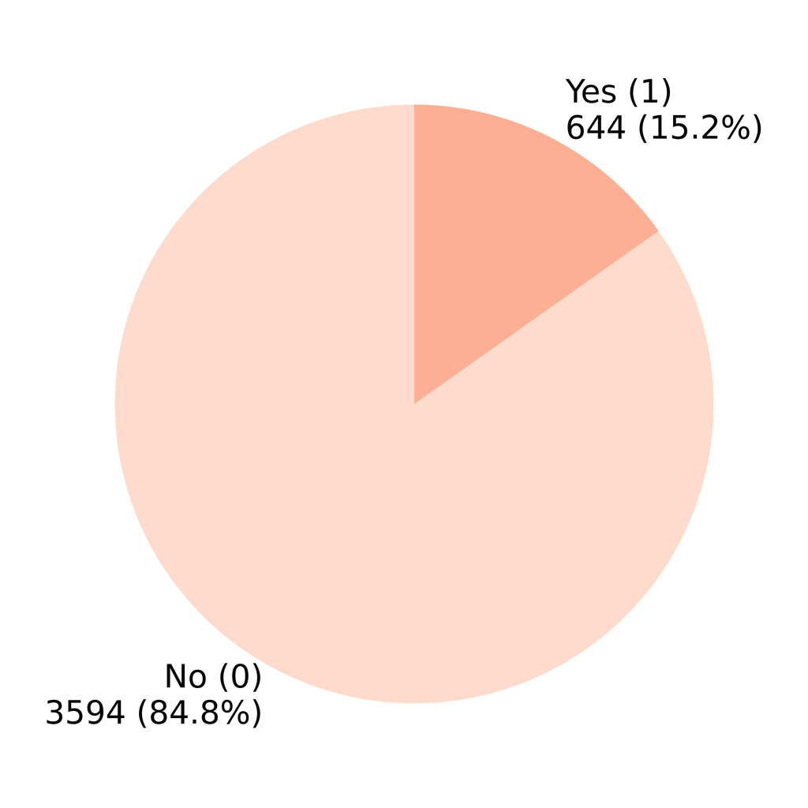

## Outcomes for Binary Features

[figure not shown]

## Outcomes for Continuous Features

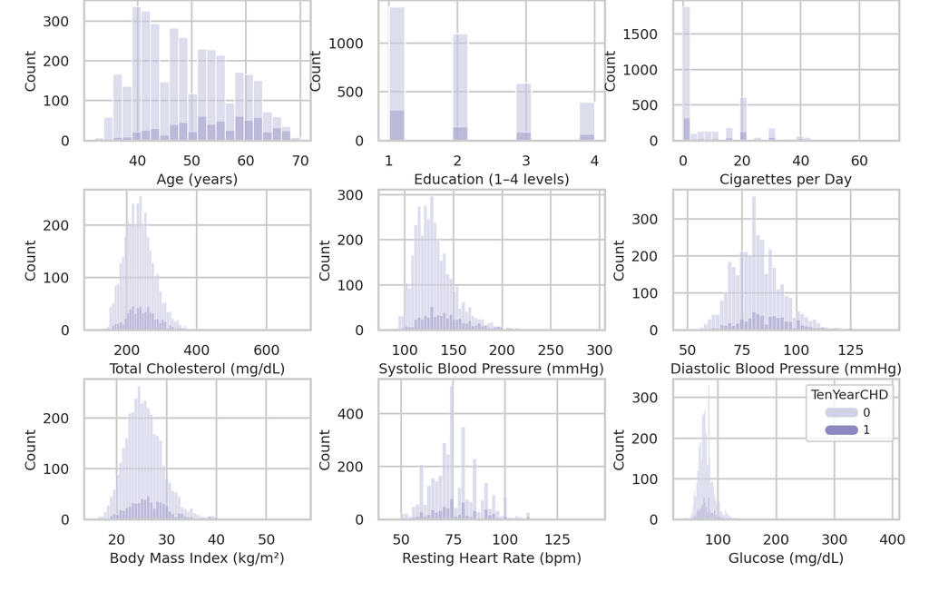

## Data Preparation

- Missing values were replaced using the mode and median.
- The mode was used for categorical and ordinal variables to preserve the most frequent categories and maintain the original distribution.
- The median was used for continuous medical variables to reduce the impact of outliers.
- The data was split into 80% training and 20% testing before feature selection to prevent data leakage.
- All predictors were scaled for consistent measurement ranges.

## Data Preparation 2

- Feature selection was performed only on the training data to keep the test set unseen during model development.
- Correlation analysis was used to identify features with strong linear relationships to the outcome.
- Recursive Feature Elimination (RFE) was used to identify features that most improved model performance.
- Using both methods helped capture complementary aspects of feature importance.
- The final predictor set was formed by combining the top features from both methods resulted in seven selected features

## Correlation Heatmap

[figure not shown]

## Model Training and Evaluation

- After feature selection, the training and testing datasets were reduced to include only the selected predictors.
- The dataset was imbalanced, with 3,594 patients without disease and 644 patients with disease.
- This imbalance could cause the model to favor predicting the majority (negative) class.
- Class weighting was applied to give more importance to the minority (positive) class during training.
- The trained model was then used to make predictions on the testing data.

## Modeling and Results

```
Accuracy: 67.80660377358491
```

```
Class 0 (Healthy): Precision 0.90 | Recall 0.69 | F1 0.79
```

```
Class 1 (Disease): Precision 0.26 | Recall 0.59 | F1 0.36
```

- The model achieved 67.8% accuracy, though accuracy is limited by class imbalance.
- Precision was high for healthy patients (90%) and low for sick patients (26%).
- Recall was 69% for healthy patients and 59% for sick patients, indicating good disease detection.
- The F1 score was strong for healthy patients (79%) and moderate for sick patients (36%).

## Confusion Matrix

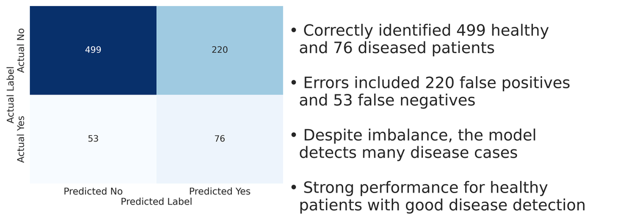

## ROC Curve

[figure not shown]

## **References**

- Bewick, Viv, Liz Cheek, and Jonathan Ball. 2005. “Statistics Review 14: Logistic Regression.” *Critical Care* 9 (1): 112–18. https://doi.org/10.1186/cc3045.
- Dayton, C Mitchell. 1992. “Logistic Regression Analysis.” *Stat* 474: 574.
- FraminghamHeartStudy. “Heart Disease Prediction.” https://www.kaggle.com/datasets/dileep070/heart-disease-prediction-using-logistic-regression; Kaggle.
- Joshi, Ram D, and Chandra K Dhakal. 2021. “Predicting Type 2 Diabetes Using Logistic Regression and Machine Learning Approaches.” *International Journal of Environmental Research and Public Health* 18 (14): 7346.
- Shipe, Maren E, Stephen A Deppen, Farhood Farjah, and Eric L Grogan. 2019. “Developing Prediction Models for Clinical Use Using Logistic Regression: An Overview.” *Journal of Thoracic Disease* 11 (Suppl 4): S574.
- Stoltzfus, Jill C. 2011. “Logistic Regression: A Brief Primer.” *Academic Emergency Medicine* 18 (10): 1099–1104. https://doi.org/10.1111/j.1553-2712.2011.01185.x.
- Tripepi, Giovanni, KJ Jager, FW Dekker, and Carmine Zoccali. 2008. “Linear and Logistic Regression Analysis.” *Kidney International* 73 (7): 806–10.
- Wang, Haolin, and Aruni Jayathilaka. 2024. “Exploring Predictive Factors for Heart Disease: A Comprehensive Analysis Using Logistic Regression.” *University of Rochester Journal of Undergraduate Research* 23 (1). https://doi.org/10.47761/YRCU1073.